# Bader Lab Human Liver

```r
library(tidyverse)
library(SingleCellExperiment)
library(scater)
library(scran)
library(Matrix)

library(Seurat)
```

# Introduction

We have prepared this notebook to serve as a guide for running CellAssign (on the MacParland et al. human liver dataset).

To see a detailed step-by-step for how to get CellAssign running on this data, please refer to the CellAssign section.

# Preprocessing

## Data acquisition

To get the list of post-QC barcodes used by the authors:

```r
# devtools::install_github('BaderLab/HumanLiver')
library(HumanLiver)

load(system.file("liver/HumanLiver.RData", package = "HumanLiver"))

HumanLiverSeurat@raw.data <- matrix(0, nrow = nrow(HumanLiverSeurat@data), ncol = ncol(HumanLiverSeurat@data))
rownames(HumanLiverSeurat@raw.data) <- rownames(HumanLiverSeurat@data)
colnames(HumanLiverSeurat@raw.data) <- colnames(HumanLiverSeurat@data)
HumanLiverSeurat@dr <- list()
sce_HL <- as.SingleCellExperiment(HumanLiverSeurat)
```

To get raw counts, we processed the bam files in SRA:

```r
humanliver_filtered_dirs <- Sys.glob(file.path("/datadrive/projects/cellassign-paper/data/baderlab/nick_outputs",
    "*", "outs", "filtered_gene_bc_matrices", "GRCh38"))
names(humanliver_filtered_dirs) <- basename(humanliver_filtered_dirs)

sce <- DropletUtils::read10xCounts(humanliver_filtered_dirs)

metadata <- data.frame(Sample = humanliver_filtered_dirs) %>% dplyr::mutate(patient = paste0("P",
    str_extract(Sample, "(?<=patient)[0-9]+"), "TLH"))

colData(sce) <- colData(sce) %>% data.frame(check.names = FALSE, stringsAsFactors = FALSE) %>%
    dplyr::left_join(metadata) %>% DataFrame(check.names = FALSE, stringsAsFactors = FALSE)

sce <- sce %>% scater::mutate(cellname = paste(patient, str_replace_all(Barcode,
    "\\-", "_"), sep = "_"))
```

## Preprocessing

We’ll substitute in the remainder of the data for the matrix, using the values from the `HumanLiver` R package on GitHub created by the authors (`BaderLab/HumanLiver`).

```r
sce_filtered <- sce %>% scater::filter(cellname %in% colnames(sce_HL))

# Works because the authors filtered out gene symbol duplicates
gene_ids <- get_ensembl_id(rownames(sce_HL), sce_filtered)

sce_subset <- sce_filtered[gene_ids, ]
colnames(sce_subset) <- sce_subset$cellname
rownames(sce_subset) <- rownames(sce_HL)
```

```r
cells_intersect <- intersect(colnames(sce_HL), colnames(sce_subset))

sce_merged <- sce_HL[, cells_intersect]
counts(sce_merged) <- counts(sce_subset[, cells_intersect])
sce_merged$patient <- sce_subset[, cells_intersect]$patient
```

We add cell type annotations, using the `viewHumanLiver()` function to determine the authors’ mapping between clusters and cell types:

```r
celltype_labels <- c(`1` = "Hepatocytes", `2` = "ab T cells", `3` = "Hepatocytes",
    `4` = "Macrophages", `5` = "Hepatocytes", `6` = "Hepatocytes", `7` = "Plasma cells",
    `8` = "NK cells", `9` = "gd T cells", `10` = "Macrophages", `11` = "LSECs",
    `12` = "LSECs", `13` = "LSECs", `14` = "Hepatocytes", `15` = "Hepatocytes",
    `16` = "Mature B cells", `17` = "Cholangiocytes", `18` = "gd T cells", `19` = "Erythroid cells",
    `20` = "Hepatic Stellate Cells")

sce_merged <- sce_merged %>% scater::mutate(celltype = celltype_labels[as.character(ident)],
    patient = str_extract())
```

We perform dimensionality reduction, since those slots were not properly moved over by `Seurat::Convert`.

```r
sce_merged <- runPCA(sce_merged, ntop = 1000, ncomponents = 50)
sce_merged <- runTSNE(sce_merged, use_dimred = "PCA", n_dimred = 50)
sce_merged <- runUMAP(sce_merged, use_dimred = "PCA", n_dimred = 50)
```

```r
print(sce_merged)
```

```
class: SingleCellExperiment
dim: 20007 6408
metadata(0):
assays(2): counts logcounts
rownames(20007): RP11-34P13.7 FO538757.2 ... AC233755.1 AC240274.1
rowData names(1): gene
colnames(6408): P2TLH_AAACCTGGTACGCTGC_1 P2TLH_AAACGGGAGCGAGAAA_1
  ... P5TLH_TTTGTCAGTTTAGGAA_1 P5TLH_TTTGTCATCAGCTTAG_1
colData names(12): total_counts total_features ... pct_counts_mito
  pct_counts_ribo
reducedDimNames(3): PCA TSNE UMAP
spikeNames(0):
```

# CellAssign

**Recommendation 1**: The error you encountered was a result of some library sizes in the input data being equal to zero. This occurred because size factors were computed from the subsetted SingleCellExperiment (i.e. with only marker gene rows), rather than the whole SingleCellExperiment. The `NA` values result when the model attempts to take the logarithm of zero.

Size factors should ideally be computed on the full SingleCellExperiment object. Size factors from a subsetted SCE may not be representative of the actual library size/normalization factors that should be applied to cell subsets.

(Please refer to the warning message thrown by calling `cellassign`: `It is highly recommended to supply size factors calculated using the full gene set`.)

We have additionally updated the GitHub repository for CellAssign to throw an error message when any cells with size factors of <= 0 are provided.

**Recommendation 2**: Since the experiment consists of data for multiple patients, `patient` should be included as a covariate in the design matrix `X`.

*Note*: As we processed this data from scratch in response to the reviewer inquiry, the data for one of the patients from McParland et al. was not fully processed at the time of this analysis (and as such was not included).

## Size factor computation

We begin by computing size factors on the full SingleCellExperiment:

```r
sce_merged <- scran::computeSumFactors(sce_merged, BPPARAM = MulticoreParam(10))
```

We next confirm that none of the size factors are negative or zero.

```r
summary(sizeFactors(sce_merged))
```

```
     Min.   1st Qu.    Median      Mean   3rd Qu.      Max.
 0.004849  0.463910  0.757003  1.000000  1.269547 15.252579
```

Using the marker gene matrix provided by the reviewer (we use the `marker_list_to_mat` helper function implemented in the `cellassign` package for readability):

```r
sce_merged_subset <- sce_merged %>% scater::filter(celltype %in% c("Cholangiocytes",
    "Mature B cells", "Hepatocytes"))

# Reviewer's marker gene matrix
marker_list <- list(Cholangiocytes = c("FXYD2", "KRT7", "TACSTD2", "CLDN10",
    "KRT19"), `Mature B cells` = c("MS4A1", "IGHD", "LINC00926", "TNFRSF13C",
    "VPREB3"), Hepatocytes = c("TAT-AS1", "APOA5", "ADH4", "CYP2C9", "LEAP2"))

mgi <- marker_list_to_mat(marker_list, include_other = FALSE)
```

```r
design <- model.matrix(~patient, colData(sce_merged_subset))  # design matrix for patient-specific effects

fit <- cellassign(exprs_obj = sce_merged_subset[intersect(rownames(mgi), rownames(sce_merged_subset)),
    ], marker_gene_info = mgi[intersect(rownames(mgi), rownames(sce_merged_subset)),
    ], s = sizeFactors(sce_merged_subset), X = design, shrinkage = TRUE, B = 20,
    min_delta = 2  # Set minimum LFC for marker genes -- higher values are recommended when the 'other' group is not included, or when substantial imbalance exists between cell type proportions
)
```

We annotate our results on the SingleCellExperiment, and subset for cells that are assigned with a CellAssign probability of >= 0.99.

```r
sce_merged_subset_labeled <- sce_merged_subset
colData(sce_merged_subset_labeled) <- colData(sce_merged_subset_labeled) %>%
    as.data.frame %>% cbind(fit$mle_params$gamma) %>% dplyr::mutate(max_prob = rowMaxs(fit$mle_params$gamma)) %>%
    DataFrame()

sce_merged_subset_labeled$cellassign_clust <- fit$cell_type

sce_merged_subset_labeled <- sce_merged_subset_labeled %>% scater::filter(max_prob >=
    0.99)
```

Finally, we’ll plot the cells in UMAP space:

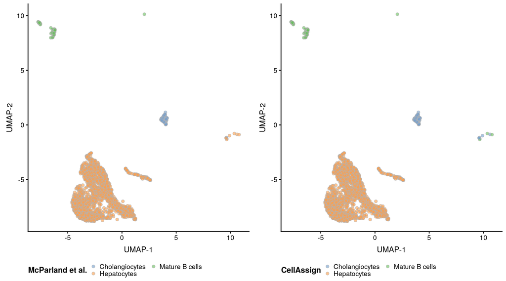

```r
## MacParland et al.
p1 <- plotUMAP(sce_merged_subset_labeled, colour_by = "celltype") + guides(fill = guide_legend(title = "McParland et al.",
    ncol = 2)) + theme(legend.position = "bottom", legend.direction = "horizontal",
    legend.key.size = unit(0.2, "cm"), legend.margin = unit(0.5, "lines"), legend.title = element_text(face = "bold"),
    legend.box.just = "left") + xlab("UMAP-1") + ylab("UMAP-2")
## CellAssign
p2 <- plotUMAP(sce_merged_subset_labeled, colour_by = "cellassign_clust") +
    guides(fill = guide_legend(title = "CellAssign", ncol = 2)) + theme(legend.position = "bottom",
    legend.direction = "horizontal", legend.key.size = unit(0.2, "cm"), legend.margin = unit(0.5,
        "lines"), legend.title = element_text(face = "bold"), legend.box.just = "left") +
    xlab("UMAP-1") + ylab("UMAP-2")

cowplot::plot_grid(p1, p2, ncol = 2, align = "hv", axis = "tblr")
```

## Contingency table

```r
with(colData(sce_merged_subset_labeled), table(celltype, cellassign_clust)) %>%
    kable %>% kable_styling()
```

|  | Cholangiocytes | Hepatocytes | Mature B cells |
| --- | --- | --- | --- |
| Cholangiocytes | 106 | 0 | 0 |
| Hepatocytes | 3 | 2330 | 4 |
| Mature B cells | 0 | 0 | 65 |